# Lab 6 with solutions

# Crank-Nicolson method

In this lab you will explore the Crank-Nicolson method and its error.

## Review

Let’s load the 3D graphics library because we will use it later.

```r
library(plot3Drgl)
```

As in previous labs, we consider again the heat equation
$$u_{t}(x,t) = K u_{xx}(x,t), \quad 0<x< L, \quad 0<t<T,$$
subject to the boundary conditions
$$u(0, t) = u(L, t)=0,$$
and initial condition $u(x,t) = u_0(x)$.

In lab 5 we investigated the backward-difference method which involves solving the matrix equation
$$A{\bf w}^{(j+1)}={\bf w}^{(j)}$$
for each $j=0,2,..,M-1$, where

$$A=\left[
\begin{array}{cccccc}
1+2\gamma &-\gamma &0 &\dots &\dots &0 \\
-\gamma &1+2\gamma &-\gamma &\ddots & &\vdots \\
0 &-\gamma &1+2\gamma &-\gamma &\ddots &\vdots \\
\vdots &\ddots &\ddots &\ddots &\ddots &0 \\
\vdots & &\ddots &\ddots &\ddots &-\gamma \\
0 &\dots &\dots &0 &-\gamma &1+2\gamma
\end{array}\right], \quad
{\bf w}^{(j)}
=\left[\begin{array}{c}
w_{1,j} \\ w_{2,j} \\ \vdots \\ \vdots \\ \vdots \\ w_{N-1,j}
\end{array}\right]$$
and $\gamma = \frac{K \tau }{h^2}$.

We used the double sweep method to solve this equation at each step, which we implemented with the following function:

```r
doublesweepOld <- function(A, B, C, F, a, b) {
    # Solves the equation
    # A[i]*v[i-1] - C[i]*v[i] + B[i]*v[i+1] = F[i]
    # for v[i], i = 1,...,N-1, with boundary conditions
    # v[0]=a and v[N]=b

    # Check the lengths of the vectors
    N <- length(C) + 1
    if ((length(B) != N-1) || (length(A) != N-1) || (length(F) != N-1)) {
        stop("The lengths of the vector arguments need to be equal")
    }

    alpha <- rep(0, N)
    beta <- rep(0, N)
    beta[1] <- a

    #sweep up to get alphas and betas
    for (i in 1:(N-1)) {
        alpha[i+1] <- B[i] / (C[i]-alpha[i]*A[i])
        beta[i+1] <- (beta[i]*A[i] - F[i]) / (C[i] - alpha[i]*A[i])
    }

    v <- rep(0, N-1 )
    v[N-1] <- alpha[N]*b + beta[N]

    #sweep down to find v's
    for (i in (N-1):2) {
        v[i-1] <- alpha[i]*v[i] + beta[i]
    }

    return(v)
}
```

This function is called once at every time step, so it is important that it runs fast. Unfortunately interpreted languages are always slow because the interpreter has to do a lot of translating and bookkeeping to do while running the code. Luckily it is easy to translate the code to C++, which is a compiled language, and in R it is easy to include code written in C++. If you are interested in learning more about this, a good place to start is http://adv-r.had.co.nz/Rcpp.html

```cpp
#include <Rcpp.h>
using namespace Rcpp;
// [[Rcpp::export]]

NumericVector doublesweep(NumericVector A, NumericVector B, NumericVector C,
                          NumericVector F, double a, double b) {
    int N = C.size() + 1;
    if ((B.size() != N-1) || (A.size() != N-1) || (F.size() != N-1)) {
        stop("The lengths of the vector arguments need to be equal");
    }

    NumericVector alpha(N);
    NumericVector beta(N);
    alpha[0] = 0;
    beta[0] = a;

    for (int i=0; i < (N-1); ++i) {
        alpha[i+1] = B[i] / (C[i]-alpha[i]*A[i]);
        beta[i+1] = (beta[i]*A[i] - F[i]) / (C[i] - alpha[i]*A[i]);
    }

    NumericVector v(N-1);
    v[N-2] = alpha[N-1]*b + beta[N-1];

    for (int i=N-2; i > 0; --i) {
        v[i-1] = alpha[i]*v[i] + beta[i];
    }

    return v;
}
```

The backward-difference method is then implemented by the function

```r
backwardDifference <- function(u0=function(x) 2*sin(2*pi*x),
                              K=1, L=1, N=30, T=0.1, M=30) {
    # set up space grid
    h <- L/N
    x <- h*(1:(N-1))

    # set up time grid
    tau <- T/M
    t <- tau*(0:M)

    # set up vectors with initial condition
    w <- u0(x)

    gamma <- K*tau/(h^2)

    Temperature <- matrix(0, N-1, M+1)  # Matrix to hold the solution
    Temperature[ , 1] <- w  # Initial value
    # Loop over time steps
    for (j in 1:M) {
        w <- doublesweep(rep(gamma, N-1), rep(gamma, N-1),
                         rep(1 + 2* gamma, N-1), -w, 0, 0)
        Temperature[ , j+1] <- w
    }

    # Return a list consisting of time grid, x grid and solution
    return(list(x=x, t=t, w=Temperature))
}
```

## Coding the Crank-Nicolson method

In this lab we want to instead use the Crank-Nicolson method, which corresponds to solving the matrix equation
$$A{\bf w}^{(j+1)}=B{\bf w}^{(j)}$$
for each $j=0,2,..,M-1$, where
$$\begin{split}
A&=\left[
\begin{array}{cccccc}
1+\gamma &-\gamma/2 &0 &\dots &\dots &0 \\
-\gamma/2 &1+\gamma &-\gamma/2 &\ddots & &\vdots \\
0 &-\gamma/2 &1+\gamma &-\gamma/2 &\ddots &\vdots \\
\vdots &\ddots &\ddots &\ddots &\ddots &0 \\
\vdots & &\ddots &\ddots &\ddots &-\gamma/2 \\
0 &\dots &\dots &0 &-\gamma/2 &1+\gamma
\end{array}\right], \\
B&=\left[
\begin{array}{cccccc}
1-\gamma &\gamma/2 &0 &\dots &\dots &0 \\
\gamma/2 &1-\gamma &\gamma/2 &\ddots & &\vdots \\
0 &\gamma/2 &1-\gamma &\gamma/2 &\ddots &\vdots \\
\vdots &\ddots &\ddots &\ddots &\ddots &0 \\
\vdots & &\ddots &\ddots &\ddots &\gamma/2 \\
0 &\dots &\dots &0 &\gamma/2 &1-\gamma
\end{array}\right].
\end{split}$$
The only change with respect to the backward-difference method is that the matrix $A$ has changed a little bit and there is now also a matrix $B$ multiplying the right-hand side. So we only have to make very minimal changes to the code for the `backwardDifference()` function to create a function that implements the Crank-Nicolson method.

### Exercise 1

Before looking at my code below, see if you can write a function for implementing the Crank-Nicolson method, based on the code for the backward-difference method.

Here is my solution. Look out for the comments starting with “# Crank-Nicolson” below to see where I made the modifications.

```r
CrankNicolson <- function(u0=function(x) 2*sin(2*pi*x),
                              K=1, L=1, N=30, T=0.1, M=30) {
    # set up space grid
    h <- L/N
    x <- h*(1:(N-1))

    # set up time grid
    tau <- T/M
    t <- tau*(0:M)

    # set up vectors with initial condition
    w <- u0(x)

    gamma <- K*tau/(h^2)
    # Crank-Nicolson needs a matrix B
    B <- diag(1-gamma, N-1)
    for (k in 1:(N-2)){
        B[k,k+1] <- gamma/2
        B[k+1,k] <- gamma/2
    }

    Temperature <- matrix(0, N-1, M+1)  # Matrix to hold the solution
    Temperature[ , 1] <- w  # Initial value
    # Loop over time steps
    for (j in 1:M) {
        # Crank-Nicolson needs different arguments to doublesweep
        # backward-difference used:
        # w <- doublesweep(rep(gamma, N-1), rep(gamma, N-1),
        #                  rep(1 + 2* gamma, N-1), -w, 0, 0)
        # Crank-Nicolson uses:
        w <- doublesweep(rep(gamma/2, N-1), rep(gamma/2, N-1),
                         rep(1 + gamma, N-1), -B%*%w, 0, 0)
        Temperature[ , j+1] <- w
    }

    # Return a list consisting of time grid, x grid and solution
    return(list(x=x, t=t, w=Temperature))
}
```

Let us check that it gives more-or-less the same result as the backward-difference method.

```r
solbd <- backwardDifference(N=300, M=300)
solCN <- CrankNicolson(N=300, M=300)
max(solbd$w - solCN$w)
```

```
[1] 0.004825172
```

## Errors in the Crank-Nicolson method

The reason we might prefer the Crank-Nicolson method to the backward-difference method is that the truncation error gets smaller faster as the time step $\tau$ is made smaller, because the truncation error is of $O(\tau^2+h^2)$ instead of $O(\tau+h^2)$. You are now asked to explore how that manifests itself in practice in the example of the heat equation.

In the previous lab we wrote a function that calculates the error in the solution from the backward-difference method with a given number $N$ of space steps and the number $M$ of time steps. We now modify the function slightly so that it takes a third argument the function we use to solve the equation

```r
maxError <- function(N, M, method) {
    # numerical solution
    numSol <- method(M=M, N=N)
    # exact solution
    x <- numSol$x
    t <- numSol$t
    xy <- mesh(x, t)
    u <- with(xy, 2*sin(2*pi*x)*exp(-4*pi^2*y))

    return(max(abs(u - numSol$w)))
}
```

We can now see that also for a small number of steps the Crank-Nicolson method beats the backward-difference method:

```r
maxError(30, 30, backwardDifference)
```

```
[1] 0.04819701
```

```r
maxError(30, 30, CrankNicolson)
```

```
[1] 0.001623436
```

But more importantly: when we double the number of steps in both directions, the error in the backward-difference reduces only by a factor of 2 (due only being first order in $\tau$) whereas the error in the Crank-Nicolson method reduces by a factor of 4.

```r
maxError(60, 60, backwardDifference)
```

```
[1] 0.02420686
```

```r
maxError(60, 60, CrankNicolson)
```

```
[1] 0.0004073176
```

Let’s make a log-log plot of the error against the number $N$ of steps, where we keep $M=N$. You will need to be a bit patient while this code is running.

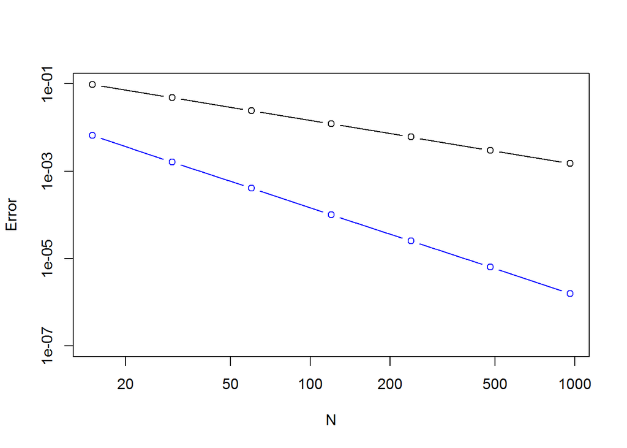

```r
N <- 15*2^(0:6)
errbd <- sapply(N, function(N) maxError(N, N, backwardDifference))
errCN <- sapply(N, function(N) maxError(N, N, CrankNicolson))
plot(errbd ~ N, type="b", log="xy", ylim=c(0.0000001, 0.1), ylab="Error")
lines(errCN ~ N, type="b", col="blue")
```

While you are waiting, let’s look more closely at the code. The `sapply` function is given a vector of values $N$ and a function and it applies the function to each value in the vector in turn and returns another vector with all the function values.

For the plot command we chose to use the `~` notation. You should read this as “as a function of”, so we are plotting the errors as a function of $N$. The `log="xy"` option told R to use logarithmic axes in both the x and the y direction.

One the calculation completes you will see that the error in the backward difference method follows a line of slope -1 on the log-log plot, meaning that the error goes down as $1/N$, whereas the error in the Crank-Nicolson method follows a line of slope -2, meaning that the error goes down as $1/N^2$.

### Exercise 2

Make a similar plot but keeping $M=60$ while varying $N$. Describe what you observe. Can you understand this observation?

### Solution 2

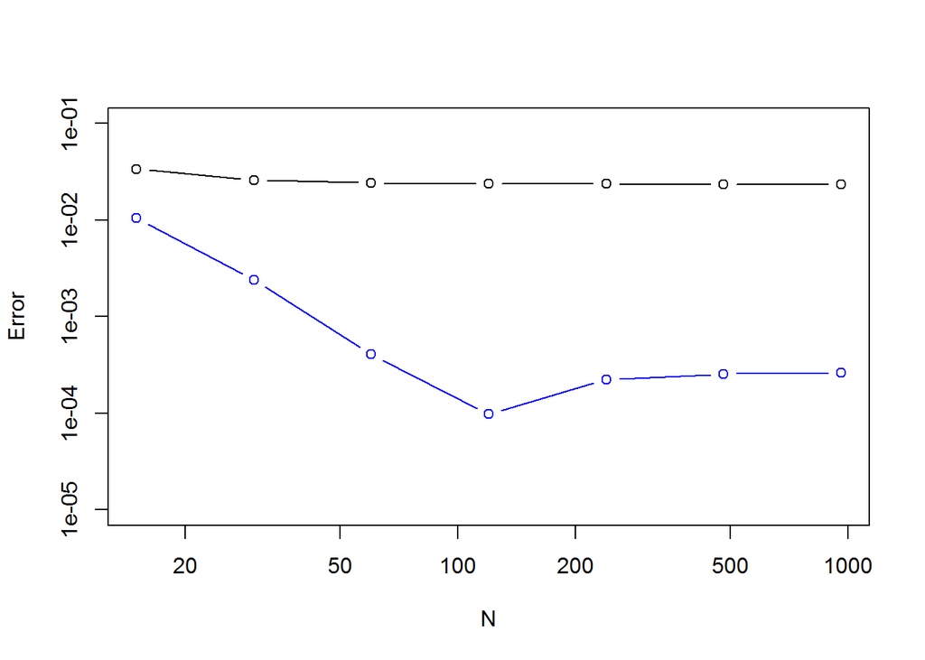

```r
N <- 15*2^(0:6)
M <- 60
errbdN <- sapply(N, function(N) maxError(N, M, backwardDifference))
errCNN <- sapply(N, function(N) maxError(N, M, CrankNicolson))
plot(errbdN ~ N, type="b", log="xy", ylim=c(0.00001, 0.1), ylab="Error")
lines(errCNN ~ N, type="b", col="blue")
```

We notice that the error of the backward difference method is determined by the time step size and decreasing the x step size does not make a difference. For the Crank Nicolson method the limiting error for the given time step is much smaller and is reached only when there are about 120 x steps.

### Exercise 3

Now make a similar plot keeping $N=60$ fixed and varying $M$. Again, can you understand the observation?

### Solution 3

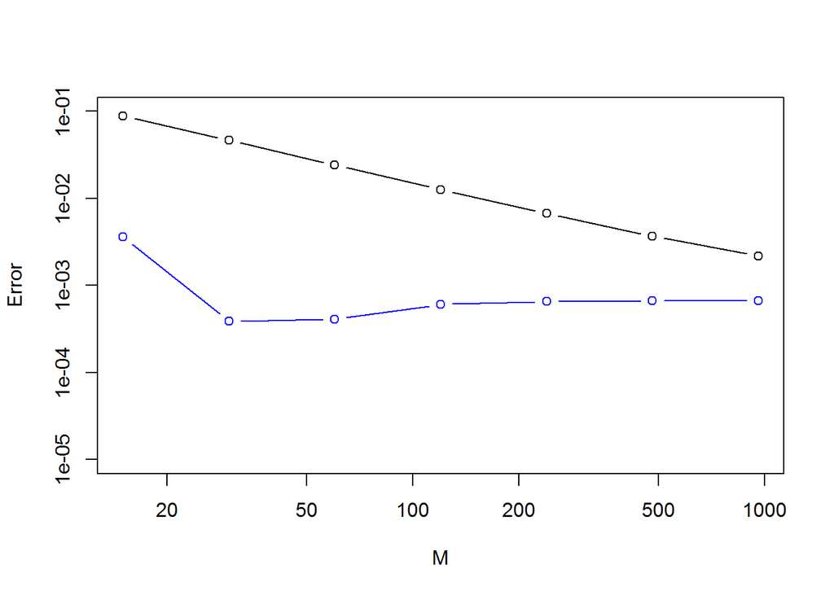

```r
M <- 15*2^(0:6)
N <- 60
errbdM <- sapply(M, function(M) maxError(N, M, backwardDifference))
errCNM <- sapply(M, function(M) maxError(N, M, CrankNicolson))
plot(errbdM ~ M, type="b", log="xy", ylim=c(0.00001, 0.1), ylab="Error")
lines(errCNM ~ M, type="b", col="blue")
```

### Exercise 4

Investigate how the error changes as the initial condition is more rapidly oscillating by changing it from $u_0(x) = 2\sin(2\pi x)$ to $u_0(x) = 2\sin(8\pi x)$. For this you will need to modify the function `maxError` appropriately.

### Solution 4

We have to change the call to the numerical method to include the `u0`argument and we have to change the expression for the exact solution `u`:

```r
maxError2 <- function(N, M, method) {
    # numerical solution
    numSol <- method(u0=function(x) 2*sin(8*pi*x), M=M, N=N)
    # exact solution
    x <- numSol$x
    t <- numSol$t
    xy <- mesh(x, t)
    u <- with(xy, 2*sin(8*pi*x)*exp(-64*pi^2*y))

    return(max(abs(u - numSol$w)))
}
```

We see that the errors are much larger now:

```r
maxError(30, 30, backwardDifference)
```

```
[1] 0.04819701
```

```r
maxError2(30, 30, backwardDifference)
```

```
[1] 0.4240666
```

```r
maxError(30, 30, CrankNicolson)
```

```
[1] 0.001623436
```

```r
maxError2(30, 30, CrankNicolson)
```

```
[1] 0.2348529
```

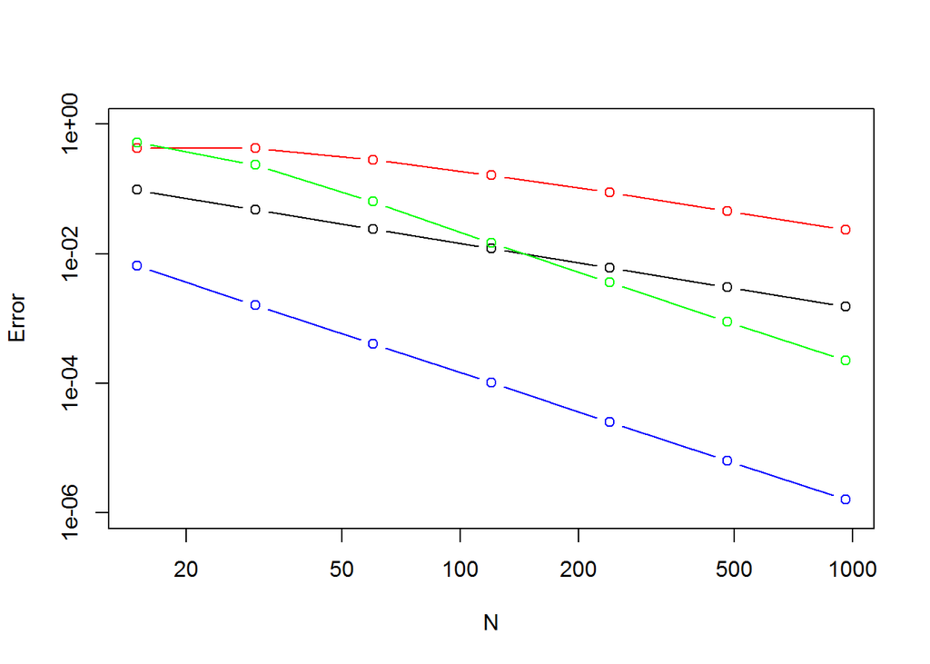

```r
N <- 15*2^(0:6)
errbd2 <- sapply(N, function(N) maxError2(N, N, backwardDifference))
errCN2 <- sapply(N, function(N) maxError2(N, N, CrankNicolson))
plot(errbd ~ N, type="b", log="xy", ylim=c(0.000001, 1), ylab="Error")
lines(errCN ~ N, type="b", col="blue")
lines(errbd2 ~ N, type="b", col="red")
lines(errCN2 ~ N, type="b", col="green")
```